# Bikeshare_SpaceTime_Prediction

- Show All Code
- Hide All Code
- View Source

CPLN 5080 - Spring 2026

Author

Jenny

Published

May 23, 2026

# INTRODUCTION

## The Rebalancing Challenge in Philadelphia

Philadelphia’s Indego bike share system faces the same operational challenge as every bike share system: **rebalancing bikes to meet anticipated demand**.

This report builds predictive models that forecast bike share demand across space (different stations) and time (different hours) to help solve this problem. The first part of the report explores data from Q1 2025 (January through March) and tests various temporal, weather, demographic, and spatial features to find the best model for predicting hourly trip demand at the station level. Through a series of progressively more complex linear models, we identify which predictors drive the most improvement in forecast accuracy. The second part applies the same workflowto Q4 2025 (October through December), which had interesting weather patterns, warm October followed by a cold snap in mid-December, as well as notable holidays including Thanksgiving, and Christmas. Three additional features were engineered, specifically holiday indicators, a nice weather feature, and distance to the nearest bike lane.

By comparing the first part of the year to the last, this report aim to understand how seasons shape ridership behaviour and model performance, if predictors that matter most in winter carry over to fall, and what the error patterns reveal about which communities and time periods are hardest to predict. These two quarters offer a better picture of the operational and equity dimensions of deploying a bike share prediction system in Philadelphia.

```r
library(tidyverse)
library(lubridate)
library(sf)
library(tigris)
library(tidycensus)
library(riem)  # For Philadelphia weather from ASOS stations

library(viridis) # color scales for visualization
library(knitr)
library(kableExtra)
library(patchwork)


library(here)
options(scipen = 999) # Get rid of scientific notation to make it look tidier
```

## Q1 Indego Trip Data (Q1 2025)

```r
# Read Q1 2025 data
indego <- read_csv(here("data/indego-trips-2025-q1.csv"))

# Quick look at the data
glimpse(indego)
```

```
Rows: 201,588
Columns: 15
$ trip_id             <dbl> 1123985990, 1123986350, 1124202498, 1123986241, 11…
$ duration            <dbl> 5, 14, 894, 9, 13, 11, 15, 19, 20, 24, 26, 11, 12,…
$ start_time          <chr> "1/1/2025 0:00", "1/1/2025 0:04", "1/1/2025 0:05",…
$ end_time            <chr> "1/1/2025 0:05", "1/1/2025 0:18", "1/1/2025 14:59"…
$ start_station       <dbl> 3371, 3344, 3021, 3253, 3182, 3346, 3049, 3112, 31…
$ start_lat           <dbl> 39.95340, 39.95961, 39.95390, 39.93074, 39.95081, …
$ start_lon           <dbl> -75.15430, -75.23354, -75.16902, -75.18924, -75.16…
$ end_station         <dbl> 3378, 3294, 3073, 3253, 3249, 3000, 3100, 3035, 33…
$ end_lat             <dbl> 39.95238, 39.95174, 39.96143, 39.93074, 39.95784, …
$ end_lon             <dbl> -75.14728, -75.17063, -75.15242, -75.18924, -75.19…
$ bike_id             <chr> "22580", "31417", "31393", "31434", "22872", "1187…
$ plan_duration       <dbl> 30, 365, 1, 30, 1, 365, 30, 30, 365, 365, 30, 365,…
$ trip_route_category <chr> "One Way", "One Way", "One Way", "Round Trip", "On…
$ passholder_type     <chr> "Indego30", "Indego365", "Walk-up", "Indego30", "W…
$ bike_type           <chr> "electric", "electric", "electric", "electric", "e…
```

## Examine the Data Structure

```r
# How many trips?
cat("Total trips in Q1 2025:", nrow(indego), "\n")
```

```
Total trips in Q1 2025: 201588
```

```r
# Date range
cat("Date range:",
    min(mdy_hm(indego$start_time)), "to",
    max(mdy_hm(indego$start_time)), "\n")
```

```
Date range: 1735689600 to 1743464880
```

```r
# How many unique stations?
cat("Unique start stations:", length(unique(indego$start_station)), "\n")
```

```
Unique start stations: 265
```

```r
# Trip types
table(indego$trip_route_category)
```

```
   One Way Round Trip
    190792      10796
```

```r
# Passholder types
table(indego$passholder_type)
```

```
  Day Pass   Indego30  Indego365 IndegoFlex    Walk-up
      5494      94044      91628          3      10419
```

```r
# Bike types
table(indego$bike_type)
```

```
electric standard
  129561    72027
```

## Create Time Bins

We need to aggregate trips into hourly intervals for our panel data structure. Read up on the lubridate library for more information on the date/time data extraction.

```r
indego <- indego %>%
  mutate(
    # Parse datetime
    start_datetime = mdy_hm(start_time),
    end_datetime = mdy_hm(end_time),

    # Create hourly bins
    interval60 = floor_date(start_datetime, unit = "hour"),

    # Extract time features
    week = week(interval60),
    month = month(interval60, label = TRUE),
    dotw = wday(interval60, label = TRUE),
    hour = hour(interval60),
    date = as.Date(interval60),

    # Create useful indicators
    weekend = ifelse(dotw %in% c("Sat", "Sun"), 1, 0),
    rush_hour = ifelse(hour %in% c(7, 8, 9, 16, 17, 18), 1, 0)
  )

# Look at temporal features
head(indego %>% select(start_datetime, interval60, week, dotw, hour, weekend))
```

```
# A tibble: 6 × 6
  start_datetime      interval60           week dotw   hour weekend
  <dttm>              <dttm>              <dbl> <ord> <int>   <dbl>
1 2025-01-01 00:00:00 2025-01-01 00:00:00     1 Wed       0       0
2 2025-01-01 00:04:00 2025-01-01 00:00:00     1 Wed       0       0
3 2025-01-01 00:05:00 2025-01-01 00:00:00     1 Wed       0       0
4 2025-01-01 00:05:00 2025-01-01 00:00:00     1 Wed       0       0
5 2025-01-01 00:08:00 2025-01-01 00:00:00     1 Wed       0       0
6 2025-01-01 00:14:00 2025-01-01 00:00:00     1 Wed       0       0
```

# EDA OF INDEGO DATA

## Trips Over Time

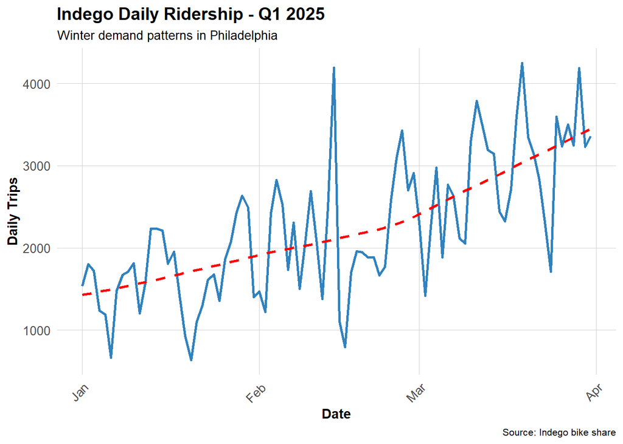

```r
# Daily trip counts
daily_trips <- indego %>%
  group_by(date) %>%
  summarize(trips = n())

ggplot(daily_trips, aes(x = date, y = trips)) +
  geom_line(color = "#3182bd", linewidth = 1) +
  geom_smooth(se = FALSE, color = "red", linetype = "dashed") +
  labs(
    title = "Indego Daily Ridership - Q1 2025",
    subtitle = "Winter demand patterns in Philadelphia",
    x = "Date",
    y = "Daily Trips",
    caption = "Source: Indego bike share"
  ) +
  plotTheme
```

```r
fly_eagles_fly <- daily_trips %>% filter(date == "2025-02-14")

typical_boring_friday <- indego %>%
  filter(dotw == "Fri", date != "2025-02-14") %>%
  group_by(date) %>%
  summarize(trips = n()) %>%
  summarize(avg_friday_trips = mean(trips))

print(fly_eagles_fly)
```

```
# A tibble: 1 × 2
  date       trips
  <date>     <int>
1 2025-02-14  4192
```

```r
print(typical_boring_friday)
```

```
# A tibble: 1 × 1
  avg_friday_trips
             <dbl>
1            2319.
```

## Hourly Patterns

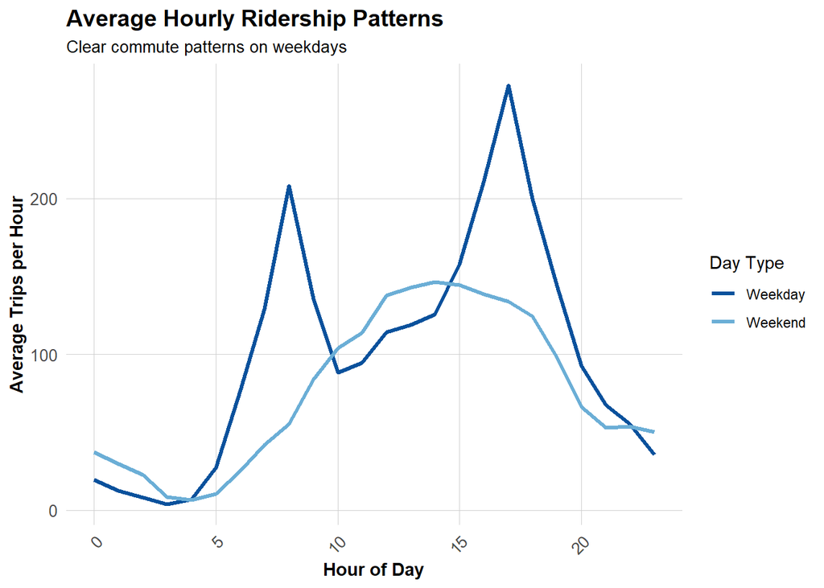

```r
# Average trips by hour and day type
hourly_patterns <- indego %>%
  group_by(hour, weekend) %>% #group by hour within each weekend vs weekday
  summarize(avg_trips = n() / n_distinct(date)) %>% #total trips divided by total unique dates (rn there are multiple of the same dates/ station)
  mutate(day_type = ifelse(weekend == 1, "Weekend", "Weekday"))

ggplot(hourly_patterns, aes(x = hour, y = avg_trips, color = day_type)) +
  geom_line(linewidth = 1.2) +
  scale_color_manual(values = c("Weekday" = "#08519c", "Weekend" = "#6baed6")) +
  labs(
    title = "Average Hourly Ridership Patterns",
    subtitle = "Clear commute patterns on weekdays",
    x = "Hour of Day",
    y = "Average Trips per Hour",
    color = "Day Type"
  ) +
  plotTheme
```

## Top Stations

```r
# Most popular origin stations
top_stations <- indego %>%
  count(start_station, start_lat, start_lon, name = "trips") %>% #how many rows fall within this combination then nameing this count as trips
  arrange(desc(trips)) %>%
  head(20)

kable(top_stations,
      caption = "Top 20 Indego Stations by Trip Origins",
      format.args = list(big.mark = ",")) %>%
  kable_styling(bootstrap_options = c("striped", "hover"))
```

Top 20 Indego Stations by Trip Origins

| start_station | start_lat | start_lon | trips |
| --- | --- | --- | --- |
| 3,010 | 39.94711 | -75.16618 | 3,999 |
| 3,032 | 39.94527 | -75.17971 | 2,842 |
| 3,359 | 39.94888 | -75.16978 | 2,699 |
| 3,020 | 39.94855 | -75.19007 | 2,673 |
| 3,208 | 39.95048 | -75.19324 | 2,503 |
| 3,244 | 39.93865 | -75.16674 | 2,486 |
| 3,066 | 39.94561 | -75.17348 | 2,396 |
| 3,362 | 39.94816 | -75.16226 | 2,387 |
| 3,012 | 39.94218 | -75.17747 | 2,361 |
| 3,028 | 39.94061 | -75.14958 | 2,348 |
| 3,161 | 39.95486 | -75.18091 | 2,278 |
| 3,101 | 39.94295 | -75.15955 | 2,274 |
| 3,295 | 39.95028 | -75.16027 | 2,160 |
| 3,054 | 39.96250 | -75.17420 | 2,123 |
| 3,185 | 39.95169 | -75.15888 | 2,116 |
| 3,038 | 39.94781 | -75.19409 | 2,111 |
| 3,203 | 39.94077 | -75.17227 | 2,106 |
| 3,059 | 39.96244 | -75.16121 | 2,027 |
| 3,022 | 39.95472 | -75.18323 | 2,014 |
| 3,063 | 39.94633 | -75.16980 | 2,014 |

# PUT DATA IN CONTEXT

## Load Philadelphia Census Data

We’ll get census tract data to add demographic context to our stations.

```r
# Get Philadelphia census tracts
philly_census <- get_acs(
  geography = "tract",
  variables = c(
    "B01003_001",  # Total population
    "B19013_001",  # Median household income
    "B08301_001",  # Total commuters
    "B08301_010",  # Commute by transit
    "B02001_002",  # White alone
    "B25077_001"   # Median home value
  ),
  state = "PA",
  county = "Philadelphia",
  year = 2022,
  geometry = TRUE,
  output = "wide"
) %>%
  rename(
    Total_Pop = B01003_001E,
    Med_Inc = B19013_001E,
    Total_Commuters = B08301_001E,
    Transit_Commuters = B08301_010E,
    White_Pop = B02001_002E,
    Med_Home_Value = B25077_001E
  ) %>%
  mutate(
    Percent_Taking_Transit = (Transit_Commuters / Total_Commuters) * 100,
    Percent_White = (White_Pop / Total_Pop) * 100
  ) %>%
  st_transform(crs = 4326)  #transforming to WGS84 for lat/lon matching, currently in NAD83
# Check the data
glimpse(philly_census)
```

```
Rows: 408
Columns: 17
$ GEOID                  <chr> "42101001500", "42101001800", "42101002802", "4…
$ NAME                   <chr> "Census Tract 15; Philadelphia County; Pennsylv…
$ Total_Pop              <dbl> 3251, 3300, 5720, 4029, 4415, 1815, 3374, 2729,…
$ B01003_001M            <dbl> 677, 369, 796, 437, 853, 210, 480, 734, 763, 11…
$ Med_Inc                <dbl> 110859, 114063, 78871, 61583, 32347, 48581, 597…
$ B19013_001M            <dbl> 24975, 30714, 20396, 22293, 4840, 13812, 6278, …
$ Total_Commuters        <dbl> 2073, 2255, 3032, 2326, 1980, 969, 2427, 708, 2…
$ B08301_001M            <dbl> 387, 308, 478, 383, 456, 189, 380, 281, 456, 68…
$ Transit_Commuters      <dbl> 429, 123, 685, 506, 534, 192, 658, 218, 438, 51…
$ B08301_010M            <dbl> 188, 66, 219, 144, 285, 71, 278, 184, 176, 235,…
$ White_Pop              <dbl> 2185, 2494, 3691, 3223, 182, 984, 2111, 231, 35…
$ B02001_002M            <dbl> 268, 381, 592, 380, 88, 190, 463, 112, 238, 778…
$ Med_Home_Value         <dbl> 568300, 605000, 350600, 296400, 76600, 289700, …
$ B25077_001M            <dbl> 58894, 34876, 12572, 22333, 10843, 118720, 1506…
$ geometry               <MULTIPOLYGON [°]> MULTIPOLYGON (((-75.16558 3..., MU…
$ Percent_Taking_Transit <dbl> 20.694645, 5.454545, 22.592348, 21.754084, 26.9…
$ Percent_White          <dbl> 67.2100892, 75.5757576, 64.5279720, 79.9950360,…
```

## Map Philadelphia Context

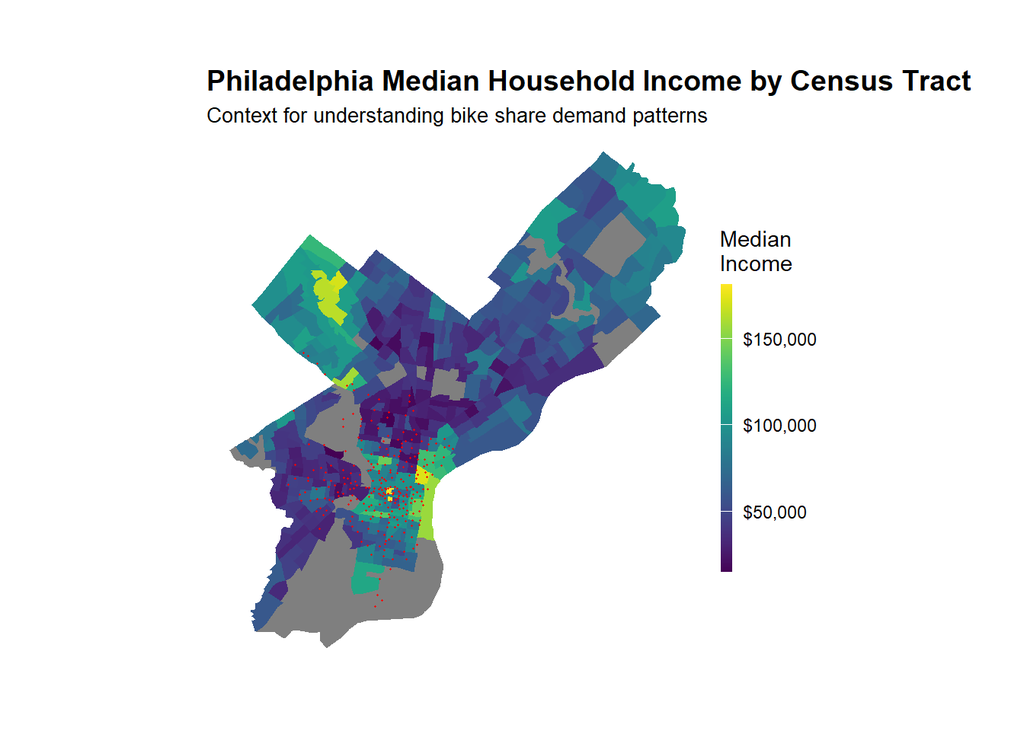

```r
# Map median income
ggplot() +
  geom_sf(data = philly_census, aes(fill = Med_Inc), color = NA) +
  scale_fill_viridis(
    option = "viridis",
    name = "Median\nIncome",
    labels = scales::dollar
  ) +
  labs(
    title = "Philadelphia Median Household Income by Census Tract",
    subtitle = "Context for understanding bike share demand patterns"
  ) +
  # Stations
  geom_point(
    data = indego,
    aes(x = start_lon, y = start_lat),
    color = "red", size = 0.25, alpha = 0.6
  ) +
  mapTheme
```

## Join Census Data to Stations

We’ll spatially join census characteristics to each bike station.

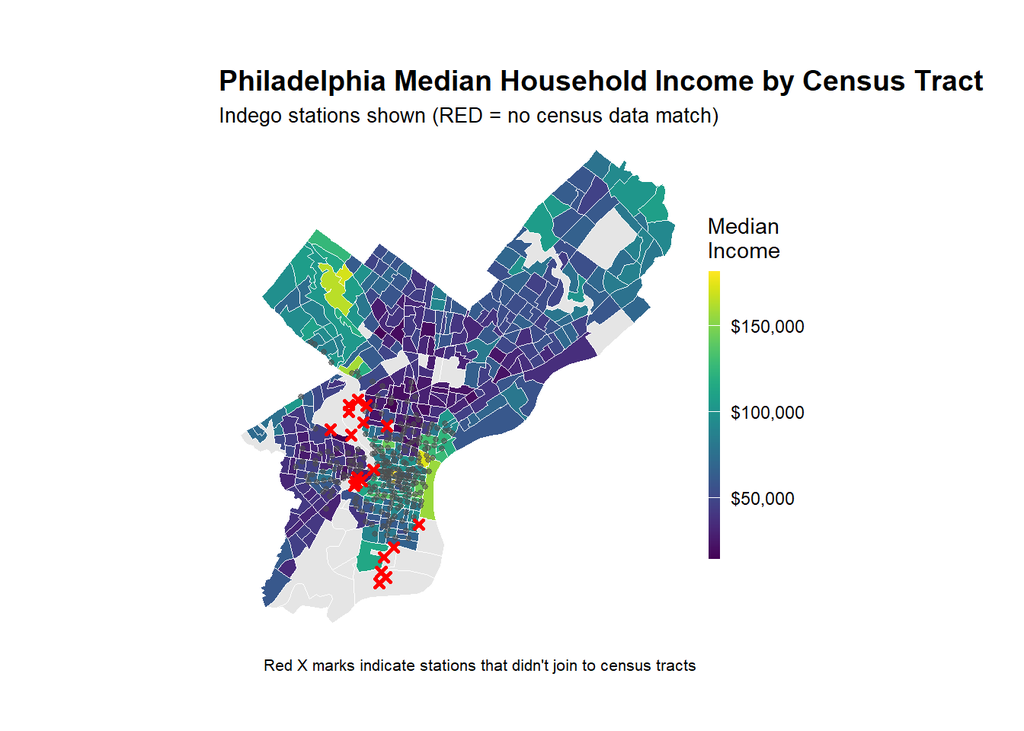

```r
# Create sf object for stations
stations_sf <- indego %>%
  distinct(start_station, start_lat, start_lon) %>% #keeps only the unique combos bc there is so many repeated dates and locations, this will collapse it into one row/station
  filter(!is.na(start_lat), !is.na(start_lon)) %>% #to prevent issues when we use the st_as_sf below, we have to remove all the NA values from LAT and LON columns
  st_as_sf(coords = c("start_lon", "start_lat"), crs = 4326)

# Spatial join to get census tract for each station
stations_census <- st_join(stations_sf, philly_census, left = TRUE) %>%
  st_drop_geometry() #we have to drop the geometry here because both philly_census and stations_sf have data. one needs to be removed so it can be joined. When we do a left join here, all rows from sation_sf stay, and even if it doesnt have a match in philly_census, it will appear with an NA.

# Look at the result - investigate whether all of the stations joined to census data -- according to the map above there are stations in non-residential tracts.

stations_for_map <- indego %>%
  distinct(start_station, start_lat, start_lon) %>%
  filter(!is.na(start_lat), !is.na(start_lon)) %>%
  left_join(
    stations_census %>% select(start_station, Med_Inc),
    by = "start_station" #Joins median income to each station via station name, but we have to select only Med_Inc so not everything is joined.
  ) %>%
  mutate(has_census = !is.na(Med_Inc)) #creates a boolean column where if a station has a CT, it will state "has_census". True when there is med income, False when there isnt.

# Add back to trip data
indego_census <- indego %>%
  left_join(
    stations_census %>%
      select(start_station, Med_Inc, Percent_Taking_Transit,
             Percent_White, Total_Pop),
    by = "start_station"
  )


# Prepare data for visualization
stations_for_map <- indego %>%
  distinct(start_station, start_lat, start_lon) %>%
  filter(!is.na(start_lat), !is.na(start_lon)) %>%
  left_join(
    stations_census %>% select(start_station, Med_Inc),
    by = "start_station"
  ) %>%
  mutate(has_census = !is.na(Med_Inc))

# Create the map showing problem stations
ggplot() +
  geom_sf(data = philly_census, aes(fill = Med_Inc), color = "white", size = 0.1) +
  scale_fill_viridis(
    option = "viridis",
    name = "Median\nIncome",
    labels = scales::dollar,
    na.value = "grey90"
  ) +
  # Stations with census data (small grey dots)
  geom_point(
    data = stations_for_map %>% filter(has_census),
    aes(x = start_lon, y = start_lat),
    color = "grey30", size = 1, alpha = 0.6
  ) +
  # Stations WITHOUT census data (red X marks the spot)
  geom_point(
    data = stations_for_map %>% filter(!has_census),
    aes(x = start_lon, y = start_lat),
    color = "red", size = 1, shape = 4, stroke = 1.5
  ) +
  labs(
    title = "Philadelphia Median Household Income by Census Tract",
    subtitle = "Indego stations shown (RED = no census data match)",
    caption = "Red X marks indicate stations that didn't join to census tracts"
  ) +
  mapTheme
```

## Dealing with missing data

We need to decide what to do with the non-residential bike share stations. For this example, we are going to remove them – this is not necessarily the right way to do things always, but for the sake of simplicity, we are narrowing our scope to only stations in residential neighborhoods. We might opt to create a separate model for non-residential stations..

```r
# Identify which stations to keep
valid_stations <- stations_census %>%
  filter(!is.na(Med_Inc)) %>%
  pull(start_station)

# Filter trip data to valid stations only
indego_census <- indego %>%
  filter(start_station %in% valid_stations) %>%
  left_join(
    stations_census %>%
      select(start_station, Med_Inc, Percent_Taking_Transit,
             Percent_White, Total_Pop),
    by = "start_station"
  )
```

## Get Weather Data

Weather significantly affects bike share demand! Let’s get hourly weather for Philadelphia.

```r
# Get weather from Philadelphia International Airport (KPHL)
# This covers Q1 2025: January 1 - March 31
weather_data <- riem_measures(
  station = "PHL",  # Philadelphia International Airport
  date_start = "2025-01-01",
  date_end = "2025-03-31"
)

# Process weather data
weather_processed <- weather_data %>%
  mutate(
    interval60 = floor_date(valid, unit = "hour"),
    Temperature = tmpf,  # Temperature in Fahrenheit
    Precipitation = ifelse(is.na(p01i), 0, p01i),  # Hourly precip in inches
    Wind_Speed = sknt  # Wind speed in knots
  ) %>%
  select(interval60, Temperature, Precipitation, Wind_Speed) %>%
  distinct(interval60, .keep_all = TRUE)

# Check for missing hours and interpolate if needed
weather_complete <- weather_processed %>%
  complete(interval60 = seq(min(interval60), max(interval60), by = "hour")) %>%
  fill(Temperature, Precipitation, Wind_Speed, .direction = "down")

# Look at the weather
summary(weather_complete %>% select(Temperature, Precipitation, Wind_Speed))
```

```
  Temperature    Precipitation        Wind_Speed
 Min.   :10.00   Min.   :0.000000   Min.   : 0.000
 1st Qu.:30.00   1st Qu.:0.000000   1st Qu.: 6.000
 Median :37.00   Median :0.000000   Median : 8.000
 Mean   :38.36   Mean   :0.001327   Mean   : 9.308
 3rd Qu.:46.00   3rd Qu.:0.000000   3rd Qu.:13.000
 Max.   :78.00   Max.   :0.280000   Max.   :30.000
```

## Visualize Weather Patterns

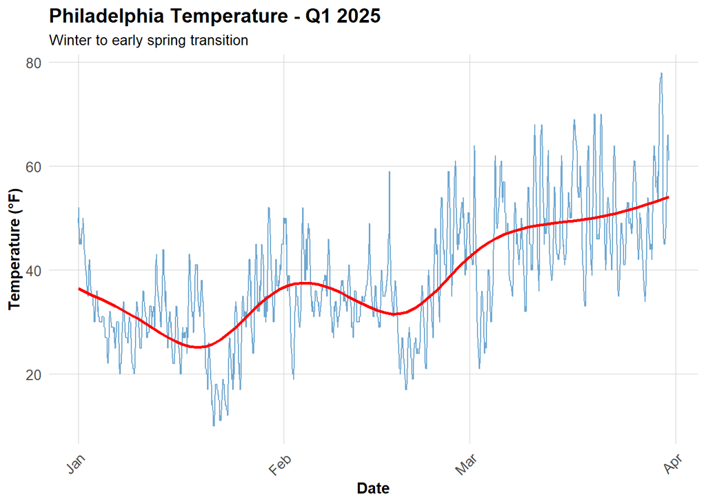

```r
ggplot(weather_complete, aes(x = interval60, y = Temperature)) +
  geom_line(color = "#3182bd", alpha = 0.7) +
  geom_smooth(se = FALSE, color = "red") +
  labs(
    title = "Philadelphia Temperature - Q1 2025",
    subtitle = "Winter to early spring transition",
    x = "Date",
    y = "Temperature (°F)"
  ) +
  plotTheme
```

# CREATE SPACE-TIME PANEL

## Aggregate Trips to Station-Hour Level

```r
# Count trips by station-hour
trips_panel <- indego_census %>%
  group_by(interval60, start_station, start_lat, start_lon,
           Med_Inc, Percent_Taking_Transit, Percent_White, Total_Pop) %>%
  summarize(Trip_Count = n()) %>%
  ungroup()

# How many station-hour observations?
nrow(trips_panel)
```

```
[1] 116718
```

```r
# How many unique stations?
length(unique(trips_panel$start_station))
```

```
[1] 245
```

```r
# How many unique hours?
length(unique(trips_panel$interval60))
```

```
[1] 2150
```

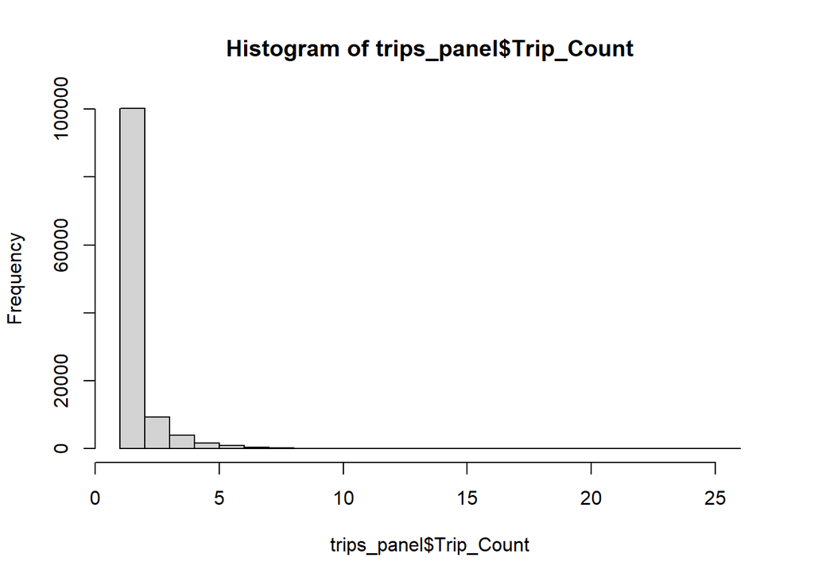

```r
hist(trips_panel$Trip_Count)
```

## Create Complete Panel Structure

Not every station has trips every hour. We need a **complete panel** where every station-hour combination exists (even if Trip_Count = 0).

```r
# Calculate expected panel size
n_stations <- length(unique(trips_panel$start_station))
n_hours <- length(unique(trips_panel$interval60))
expected_rows <- n_stations * n_hours

cat("Expected panel rows:", format(expected_rows, big.mark = ","), "\n")
```

```
Expected panel rows: 526,750
```

```r
cat("Current rows:", format(nrow(trips_panel), big.mark = ","), "\n")
```

```
Current rows: 116,718
```

```r
cat("Missing rows:", format(expected_rows - nrow(trips_panel), big.mark = ","), "\n")
```

```
Missing rows: 410,032
```

```r
# Create complete panel
study_panel <- expand_grid(
  interval60 = unique(trips_panel$interval60),
  start_station = unique(trips_panel$start_station)
) %>%
  # Join trip counts
  left_join(trips_panel %>%
              select(interval60, start_station, Trip_Count),
            by = c("interval60", "start_station")) %>%
  # Replace NA trip counts with 0
  mutate(Trip_Count = replace_na(Trip_Count, 0))

glimpse(study_panel)
```

```
Rows: 526,750
Columns: 3
$ interval60    <dttm> 2025-01-01, 2025-01-01, 2025-01-01, 2025-01-01, 2025-01…
$ start_station <dbl> 3005, 3007, 3015, 3021, 3026, 3028, 3029, 3030, 3032, 30…
$ Trip_Count    <int> 6, 1, 4, 1, 2, 1, 2, 1, 1, 1, 1, 1, 1, 1, 2, 3, 1, 1, 3,…
```

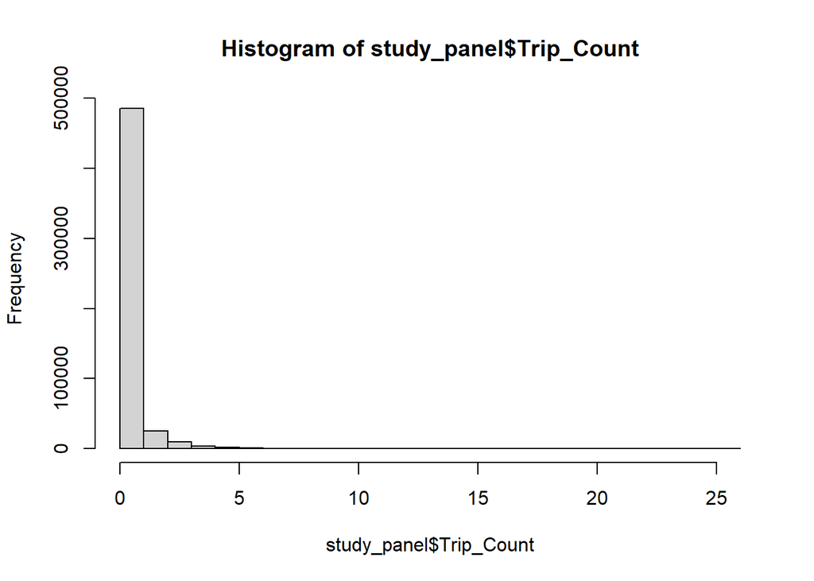

```r
hist(study_panel$Trip_Count)
```

```r
# Fill in station attributes (they're the same for all hours)
station_attributes <- trips_panel %>%
  group_by(start_station) %>%
  summarize(
    start_lat = first(start_lat),
    start_lon = first(start_lon),
    Med_Inc = first(Med_Inc),
    Percent_Taking_Transit = first(Percent_Taking_Transit),
    Percent_White = first(Percent_White),
    Total_Pop = first(Total_Pop)
  )

glimpse(station_attributes)
```

```
Rows: 245
Columns: 7
$ start_station          <dbl> 3005, 3006, 3007, 3008, 3009, 3010, 3012, 3014,…
$ start_lat              <dbl> 39.94733, 39.95220, 39.94517, 39.98081, 39.9557…
$ start_lon              <dbl> -75.14403, -75.20311, -75.15993, -75.15067, -75…
$ Med_Inc                <dbl> 144922, 21064, 58557, 22244, 37674, 88583, 1385…
$ Percent_Taking_Transit <dbl> 11.742827, 9.418565, 11.401515, 27.430556, 10.8…
$ Percent_White          <dbl> 86.29640, 46.88109, 62.85341, 39.65227, 60.2169…
$ Total_Pop              <dbl> 3583, 6156, 4598, 5349, 7375, 3134, 3643, 3914,…
```

```r
study_panel <- study_panel %>%
  left_join(station_attributes, by = "start_station")

glimpse(study_panel)
```

```
Rows: 526,750
Columns: 9
$ interval60             <dttm> 2025-01-01, 2025-01-01, 2025-01-01, 2025-01-01…
$ start_station          <dbl> 3005, 3007, 3015, 3021, 3026, 3028, 3029, 3030,…
$ Trip_Count             <int> 6, 1, 4, 1, 2, 1, 2, 1, 1, 1, 1, 1, 1, 1, 2, 3,…
$ start_lat              <dbl> 39.94733, 39.94517, 39.94735, 39.95390, 39.9418…
$ start_lon              <dbl> -75.14403, -75.15993, -75.14886, -75.16902, -75…
$ Med_Inc                <dbl> 144922, 58557, 144922, 90980, 144922, 146071, 2…
$ Percent_Taking_Transit <dbl> 11.742827, 11.401515, 11.742827, 17.800289, 11.…
$ Percent_White          <dbl> 86.29640, 62.85341, 86.29640, 79.26518, 86.2964…
$ Total_Pop              <dbl> 3583, 4598, 3583, 3130, 3583, 2428, 6267, 3300,…
```

```r
# Verify we have complete panel
cat("Complete panel rows:", format(nrow(study_panel), big.mark = ","), "\n")
```

```
Complete panel rows: 526,750
```

## Add Time Features

```r
study_panel <- study_panel %>%
  mutate(
    week = week(interval60),
    month = month(interval60, label = TRUE),
    dotw = wday(interval60, label = TRUE),
    hour = hour(interval60),
    date = as.Date(interval60),
    weekend = ifelse(dotw %in% c("Sat", "Sun"), 1, 0),
    rush_hour = ifelse(hour %in% c(7, 8, 9, 16, 17, 18), 1, 0)
  )

glimpse(study_panel)
```

```
Rows: 526,750
Columns: 16
$ interval60             <dttm> 2025-01-01, 2025-01-01, 2025-01-01, 2025-01-01…
$ start_station          <dbl> 3005, 3007, 3015, 3021, 3026, 3028, 3029, 3030,…
$ Trip_Count             <int> 6, 1, 4, 1, 2, 1, 2, 1, 1, 1, 1, 1, 1, 1, 2, 3,…
$ start_lat              <dbl> 39.94733, 39.94517, 39.94735, 39.95390, 39.9418…
$ start_lon              <dbl> -75.14403, -75.15993, -75.14886, -75.16902, -75…
$ Med_Inc                <dbl> 144922, 58557, 144922, 90980, 144922, 146071, 2…
$ Percent_Taking_Transit <dbl> 11.742827, 11.401515, 11.742827, 17.800289, 11.…
$ Percent_White          <dbl> 86.29640, 62.85341, 86.29640, 79.26518, 86.2964…
$ Total_Pop              <dbl> 3583, 4598, 3583, 3130, 3583, 2428, 6267, 3300,…
$ week                   <dbl> 1, 1, 1, 1, 1, 1, 1, 1, 1, 1, 1, 1, 1, 1, 1, 1,…
$ month                  <ord> Jan, Jan, Jan, Jan, Jan, Jan, Jan, Jan, Jan, Ja…
$ dotw                   <ord> Wed, Wed, Wed, Wed, Wed, Wed, Wed, Wed, Wed, We…
$ hour                   <int> 0, 0, 0, 0, 0, 0, 0, 0, 0, 0, 0, 0, 0, 0, 0, 0,…
$ date                   <date> 2025-01-01, 2025-01-01, 2025-01-01, 2025-01-01…
$ weekend                <dbl> 0, 0, 0, 0, 0, 0, 0, 0, 0, 0, 0, 0, 0, 0, 0, 0,…
$ rush_hour              <dbl> 0, 0, 0, 0, 0, 0, 0, 0, 0, 0, 0, 0, 0, 0, 0, 0,…
```

## Join Weather Data

```r
study_panel <- study_panel %>%
  left_join(weather_complete, by = "interval60") #join weather by hour

glimpse(study_panel)
```

```
Rows: 526,750
Columns: 19
$ interval60             <dttm> 2025-01-01, 2025-01-01, 2025-01-01, 2025-01-01…
$ start_station          <dbl> 3005, 3007, 3015, 3021, 3026, 3028, 3029, 3030,…
$ Trip_Count             <int> 6, 1, 4, 1, 2, 1, 2, 1, 1, 1, 1, 1, 1, 1, 2, 3,…
$ start_lat              <dbl> 39.94733, 39.94517, 39.94735, 39.95390, 39.9418…
$ start_lon              <dbl> -75.14403, -75.15993, -75.14886, -75.16902, -75…
$ Med_Inc                <dbl> 144922, 58557, 144922, 90980, 144922, 146071, 2…
$ Percent_Taking_Transit <dbl> 11.742827, 11.401515, 11.742827, 17.800289, 11.…
$ Percent_White          <dbl> 86.29640, 62.85341, 86.29640, 79.26518, 86.2964…
$ Total_Pop              <dbl> 3583, 4598, 3583, 3130, 3583, 2428, 6267, 3300,…
$ week                   <dbl> 1, 1, 1, 1, 1, 1, 1, 1, 1, 1, 1, 1, 1, 1, 1, 1,…
$ month                  <ord> Jan, Jan, Jan, Jan, Jan, Jan, Jan, Jan, Jan, Ja…
$ dotw                   <ord> Wed, Wed, Wed, Wed, Wed, Wed, Wed, Wed, Wed, We…
$ hour                   <int> 0, 0, 0, 0, 0, 0, 0, 0, 0, 0, 0, 0, 0, 0, 0, 0,…
$ date                   <date> 2025-01-01, 2025-01-01, 2025-01-01, 2025-01-01…
$ weekend                <dbl> 0, 0, 0, 0, 0, 0, 0, 0, 0, 0, 0, 0, 0, 0, 0, 0,…
$ rush_hour              <dbl> 0, 0, 0, 0, 0, 0, 0, 0, 0, 0, 0, 0, 0, 0, 0, 0,…
$ Temperature            <dbl> 50, 50, 50, 50, 50, 50, 50, 50, 50, 50, 50, 50,…
$ Precipitation          <dbl> 0.06, 0.06, 0.06, 0.06, 0.06, 0.06, 0.06, 0.06,…
$ Wind_Speed             <dbl> 9, 9, 9, 9, 9, 9, 9, 9, 9, 9, 9, 9, 9, 9, 9, 9,…
```

```r
# Check for missing values
summary(study_panel %>% select(Trip_Count, Temperature, Precipitation))
```

```
   Trip_Count       Temperature    Precipitation
 Min.   : 0.0000   Min.   :10.00   Min.   :0.0000
 1st Qu.: 0.0000   1st Qu.:30.00   1st Qu.:0.0000
 Median : 0.0000   Median :37.00   Median :0.0000
 Mean   : 0.3585   Mean   :38.39   Mean   :0.0013
 3rd Qu.: 0.0000   3rd Qu.:46.00   3rd Qu.:0.0000
 Max.   :26.0000   Max.   :78.00   Max.   :0.2800
                   NA's   :5880    NA's   :5880
```

# CREATE TEMPORAL LAG VARIABLES

The key innovation for space-time prediction: **past demand predicts future demand**.

If there were 15 bike trips from Station A at 8:00 AM, there will probably be ~15 trips at 9:00 AM. We can use this temporal persistence to improve predictions.

**Note:** We still can’t use spatial lags in prediction. Temporal lags are different because time moves in one direction - past predicts the future, but the future does not predict the past. Spatial lags are non-directional and create circular prediction logic.

```r
# Sort by station and time
study_panel <- study_panel %>%
  arrange(start_station, interval60)

# Create lag variables WITHIN each station
study_panel <- study_panel %>%
  group_by(start_station) %>%
  mutate(
    lag1Hour = lag(Trip_Count, 1),
    lag2Hours = lag(Trip_Count, 2),
    lag3Hours = lag(Trip_Count, 3),
    lag12Hours = lag(Trip_Count, 12),
    lag1day = lag(Trip_Count, 24)
  ) %>%
  ungroup()

# Remove rows with NA lags (first 24 hours for each station)
study_panel_complete <- study_panel %>%
  filter(!is.na(lag1day))

cat("Rows after removing NA lags:", format(nrow(study_panel_complete), big.mark = ","), "\n")
```

```
Rows after removing NA lags: 520,870
```

## Visualize Lag Correlations

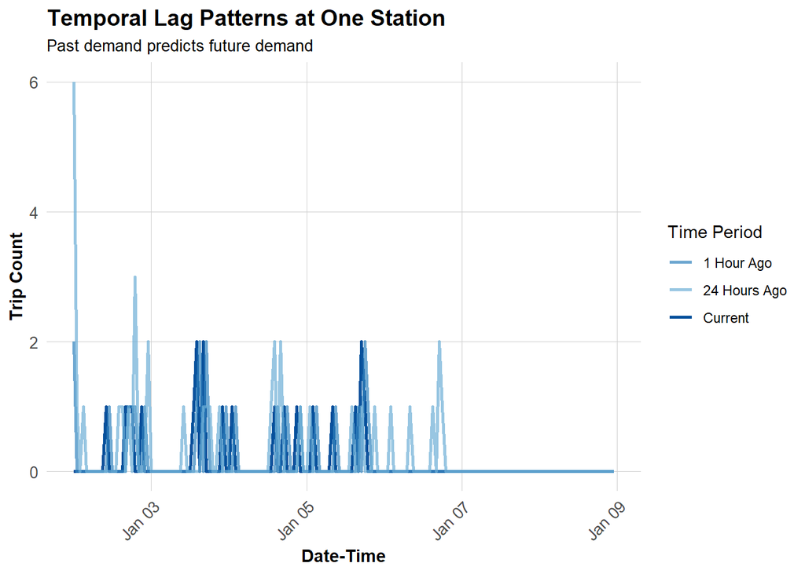

```r
# Sample one station to visualize
example_station <- study_panel_complete %>%
  filter(start_station == first(start_station)) %>%
  head(168)  # One week

# Plot actual vs lagged demand
ggplot(example_station, aes(x = interval60)) +
  geom_line(aes(y = Trip_Count, color = "Current"), linewidth = 1) +
  geom_line(aes(y = lag1Hour, color = "1 Hour Ago"), linewidth = 1, alpha = 0.7) +
  geom_line(aes(y = lag1day, color = "24 Hours Ago"), linewidth = 1, alpha = 0.7) +
  scale_color_manual(values = c(
    "Current" = "#08519c",
    "1 Hour Ago" = "#3182bd",
    "24 Hours Ago" = "#6baed6"
  )) +
  labs(
    title = "Temporal Lag Patterns at One Station",
    subtitle = "Past demand predicts future demand",
    x = "Date-Time",
    y = "Trip Count",
    color = "Time Period"
  ) +
  plotTheme
```

# TEMPORAL TRAIN/TEST SPLIT

```r
# Split by week
# Q1 has weeks 1-13 (Jan-Mar)
# Train on weeks 1-9 (Jan 1 - early March)
# Test on weeks 10-13 (rest of March)

# Which stations have trips in BOTH early and late periods?
early_stations <- study_panel_complete %>%
  filter(week < 10) %>%
  filter(Trip_Count > 0) %>%
  distinct(start_station) %>%
  pull(start_station)

late_stations <- study_panel_complete %>%
  filter(week >= 10) %>%
  filter(Trip_Count > 0) %>%
  distinct(start_station) %>%
  pull(start_station)

# Keep only stations that appear in BOTH periods
common_stations <- intersect(early_stations, late_stations)


# Filter panel to only common stations
study_panel_complete <- study_panel_complete %>%
  filter(start_station %in% common_stations)

# NOW create train/test split
train <- study_panel_complete %>%
  filter(week < 10)

test <- study_panel_complete %>%
  filter(week >= 10)

cat("Training observations:", format(nrow(train), big.mark = ","), "\n")
```

```
Training observations: 352,240
```

```r
cat("Testing observations:", format(nrow(test), big.mark = ","), "\n")
```

```
Testing observations: 153,748
```

```r
cat("Training date range:", min(train$date), "to", max(train$date), "\n")
```

```
Training date range: 20090 to 20151
```

```r
cat("Testing date range:", min(test$date), "to", max(test$date), "\n")
```

```
Testing date range: 20152 to 20178
```

# BUILD PREDICTIVE MODELS

We’ll build 5 models with increasing complexity to see what improves predictions.

## Model 1: Baseline (Time + Weather)

```r
# Create day of week factor with treatment (dummy) coding
train <- train %>%
  mutate(dotw_simple = factor(dotw, levels = c("Mon", "Tue", "Wed", "Thu", "Fri", "Sat", "Sun")))

# Set contrasts to treatment coding (dummy variables)
contrasts(train$dotw_simple) <- contr.treatment(7)

# Now run the model
model1 <- lm(
  Trip_Count ~ as.factor(hour) + dotw_simple + Temperature + Precipitation,
  data = train
)

summary(model1)
```

```
Call:
lm(formula = Trip_Count ~ as.factor(hour) + dotw_simple + Temperature +
    Precipitation, data = train)

Residuals:
    Min      1Q  Median      3Q     Max
-0.9505 -0.4005 -0.1795  0.0221 18.5359

Coefficients:
                    Estimate Std. Error t value             Pr(>|t|)
(Intercept)       -0.1865881  0.0087166 -21.406 < 0.0000000000000002 ***
as.factor(hour)1  -0.0254861  0.0087583  -2.910              0.00362 **
as.factor(hour)2  -0.0363902  0.0088009  -4.135  0.00003553166352764 ***
as.factor(hour)3  -0.0525056  0.0087645  -5.991  0.00000000209104740 ***
as.factor(hour)4  -0.0364554  0.0087381  -4.172  0.00003019750974031 ***
as.factor(hour)5   0.0230901  0.0087069   2.652              0.00800 **
as.factor(hour)6   0.1744174  0.0087150  20.014 < 0.0000000000000002 ***
as.factor(hour)7   0.3241655  0.0087182  37.183 < 0.0000000000000002 ***
as.factor(hour)8   0.5499211  0.0087229  63.044 < 0.0000000000000002 ***
as.factor(hour)9   0.3904427  0.0087209  44.771 < 0.0000000000000002 ***
as.factor(hour)10  0.2810826  0.0087269  32.209 < 0.0000000000000002 ***
as.factor(hour)11  0.2964398  0.0087321  33.948 < 0.0000000000000002 ***
as.factor(hour)12  0.3676829  0.0087199  42.166 < 0.0000000000000002 ***
as.factor(hour)13  0.3494810  0.0086973  40.183 < 0.0000000000000002 ***
as.factor(hour)14  0.3519969  0.0086887  40.512 < 0.0000000000000002 ***
as.factor(hour)15  0.4082093  0.0086904  46.972 < 0.0000000000000002 ***
as.factor(hour)16  0.4901333  0.0086951  56.369 < 0.0000000000000002 ***
as.factor(hour)17  0.6148350  0.0087059  70.623 < 0.0000000000000002 ***
as.factor(hour)18  0.4245184  0.0087149  48.712 < 0.0000000000000002 ***
as.factor(hour)19  0.2709915  0.0087215  31.072 < 0.0000000000000002 ***
as.factor(hour)20  0.1498838  0.0087168  17.195 < 0.0000000000000002 ***
as.factor(hour)21  0.0883229  0.0087071  10.144 < 0.0000000000000002 ***
as.factor(hour)22  0.0688853  0.0086978   7.920  0.00000000000000239 ***
as.factor(hour)23  0.0416985  0.0086883   4.799  0.00000159201720578 ***
dotw_simple2       0.0534158  0.0046920  11.384 < 0.0000000000000002 ***
dotw_simple3       0.0591069  0.0048452  12.199 < 0.0000000000000002 ***
dotw_simple4       0.0329187  0.0046852   7.026  0.00000000000212695 ***
dotw_simple5       0.0432028  0.0046773   9.237 < 0.0000000000000002 ***
dotw_simple6      -0.0654894  0.0046757 -14.006 < 0.0000000000000002 ***
dotw_simple7      -0.0629789  0.0047034 -13.390 < 0.0000000000000002 ***
Temperature        0.0079845  0.0001544  51.702 < 0.0000000000000002 ***
Precipitation     -2.5026380  0.1914911 -13.069 < 0.0000000000000002 ***
---
Signif. codes:  0 '***' 0.001 '**' 0.01 '*' 0.05 '.' 0.1 ' ' 1

Residual standard error: 0.746 on 352208 degrees of freedom
Multiple R-squared:  0.07881,   Adjusted R-squared:  0.07873
F-statistic:   972 on 31 and 352208 DF,  p-value: < 0.00000000000000022
```

The model uses Monday as the baseline. Each coefficient represents the difference in expected trips per station-hour compared to Monday - dow_simple2 = Tuesday..

**Weekend Pattern (Sat-Sun):**

## Model 2: Add Temporal Lags

```r
model2 <- lm(
  Trip_Count ~ as.factor(hour) + dotw_simple + Temperature + Precipitation +
    lag1Hour + lag3Hours + lag1day,
  data = train
)

summary(model2)
```

```
Call:
lm(formula = Trip_Count ~ as.factor(hour) + dotw_simple + Temperature +
    Precipitation + lag1Hour + lag3Hours + lag1day, data = train)

Residuals:
    Min      1Q  Median      3Q     Max
-4.8168 -0.2847 -0.1032  0.0169 17.7976

Coefficients:
                    Estimate Std. Error t value             Pr(>|t|)
(Intercept)       -0.0981452  0.0079807 -12.298 < 0.0000000000000002 ***
as.factor(hour)1  -0.0073089  0.0080114  -0.912              0.36161
as.factor(hour)2  -0.0056704  0.0080509  -0.704              0.48124
as.factor(hour)3  -0.0098486  0.0080187  -1.228              0.21937
as.factor(hour)4   0.0073214  0.0079952   0.916              0.35981
as.factor(hour)5   0.0541355  0.0079676   6.794  0.00000000001088671 ***
as.factor(hour)6   0.1598589  0.0079803  20.032 < 0.0000000000000002 ***
as.factor(hour)7   0.2402233  0.0079951  30.046 < 0.0000000000000002 ***
as.factor(hour)8   0.3755384  0.0080279  46.779 < 0.0000000000000002 ***
as.factor(hour)9   0.1807415  0.0080254  22.521 < 0.0000000000000002 ***
as.factor(hour)10  0.1188012  0.0080068  14.838 < 0.0000000000000002 ***
as.factor(hour)11  0.1347784  0.0080231  16.799 < 0.0000000000000002 ***
as.factor(hour)12  0.2042401  0.0080027  25.521 < 0.0000000000000002 ***
as.factor(hour)13  0.1863749  0.0079803  23.354 < 0.0000000000000002 ***
as.factor(hour)14  0.1933502  0.0079711  24.256 < 0.0000000000000002 ***
as.factor(hour)15  0.2303877  0.0079791  28.874 < 0.0000000000000002 ***
as.factor(hour)16  0.2798055  0.0079958  34.994 < 0.0000000000000002 ***
as.factor(hour)17  0.3592389  0.0080276  44.750 < 0.0000000000000002 ***
as.factor(hour)18  0.1723963  0.0080312  21.466 < 0.0000000000000002 ***
as.factor(hour)19  0.0896528  0.0080112  11.191 < 0.0000000000000002 ***
as.factor(hour)20  0.0154708  0.0080102   1.931              0.05344 .
as.factor(hour)21  0.0133420  0.0079787   1.672              0.09449 .
as.factor(hour)22  0.0257497  0.0079603   3.235              0.00122 **
as.factor(hour)23  0.0204881  0.0079476   2.578              0.00994 **
dotw_simple2       0.0203302  0.0042937   4.735  0.00000219283951014 ***
dotw_simple3       0.0107868  0.0044368   2.431              0.01505 *
dotw_simple4      -0.0016960  0.0042891  -0.395              0.69254
dotw_simple5       0.0111818  0.0042805   2.612              0.00900 **
dotw_simple6      -0.0723041  0.0042858 -16.871 < 0.0000000000000002 ***
dotw_simple7      -0.0433412  0.0043053 -10.067 < 0.0000000000000002 ***
Temperature        0.0036893  0.0001423  25.920 < 0.0000000000000002 ***
Precipitation     -1.3733842  0.1752334  -7.837  0.00000000000000461 ***
lag1Hour           0.2285048  0.0016338 139.865 < 0.0000000000000002 ***
lag3Hours          0.0974819  0.0016053  60.726 < 0.0000000000000002 ***
lag1day            0.2350577  0.0016168 145.387 < 0.0000000000000002 ***
---
Signif. codes:  0 '***' 0.001 '**' 0.01 '*' 0.05 '.' 0.1 ' ' 1

Residual standard error: 0.6823 on 352205 degrees of freedom
Multiple R-squared:  0.2293,    Adjusted R-squared:  0.2292
F-statistic:  3082 on 34 and 352205 DF,  p-value: < 0.00000000000000022
```

## Model 3: Add Demographics

```r
model3 <- lm(
  Trip_Count ~ as.factor(hour) + dotw_simple + Temperature + Precipitation +
    lag1Hour + lag3Hours + lag1day +
    Med_Inc + Percent_Taking_Transit + Percent_White,
  data = train
)

summary(model3)
```

```
Call:
lm(formula = Trip_Count ~ as.factor(hour) + dotw_simple + Temperature +
    Precipitation + lag1Hour + lag3Hours + lag1day + Med_Inc +
    Percent_Taking_Transit + Percent_White, data = train)

Residuals:
    Min      1Q  Median      3Q     Max
-4.6781 -0.2928 -0.1040  0.0416 17.7669

Coefficients:
                             Estimate     Std. Error t value
(Intercept)            -0.19313819262  0.00923311923 -20.918
as.factor(hour)1       -0.00799461927  0.00798751053  -1.001
as.factor(hour)2       -0.00692313434  0.00802697156  -0.862
as.factor(hour)3       -0.01170272248  0.00799487410  -1.464
as.factor(hour)4        0.00532779538  0.00797145169   0.668
as.factor(hour)5        0.05247025337  0.00794386290   6.605
as.factor(hour)6        0.15961351650  0.00795646144  20.061
as.factor(hour)7        0.24230559043  0.00797137108  30.397
as.factor(hour)8        0.38091625076  0.00800478190  47.586
as.factor(hour)9        0.18794185116  0.00800303366  23.484
as.factor(hour)10       0.12517589185  0.00798410205  15.678
as.factor(hour)11       0.14226414630  0.00800084164  17.781
as.factor(hour)12       0.21096634554  0.00798016494  26.436
as.factor(hour)13       0.19245141624  0.00795755375  24.185
as.factor(hour)14       0.19928012231  0.00794838591  25.072
as.factor(hour)15       0.23726523874  0.00795670102  29.820
as.factor(hour)16       0.28770940221  0.00797379314  36.082
as.factor(hour)17       0.36865408137  0.00800627902  46.046
as.factor(hour)18       0.18193513668  0.00800987884  22.714
as.factor(hour)19       0.09728716206  0.00798900814  12.178
as.factor(hour)20       0.02225418222  0.00798764893   2.786
as.factor(hour)21       0.01731586919  0.00795540485   2.177
as.factor(hour)22       0.02800711868  0.00793668256   3.529
as.factor(hour)23       0.02147968094  0.00792394388   2.711
dotw_simple2            0.02163608068  0.00428100242   5.054
dotw_simple3            0.01263479071  0.00442375706   2.856
dotw_simple4           -0.00043701988  0.00427636580  -0.102
dotw_simple5            0.01241705386  0.00426785841   2.909
dotw_simple6           -0.07235969603  0.00427299524 -16.934
```

[output cut: 39 more lines]

```
dotw_simple7           < 0.0000000000000002 ***
Temperature            < 0.0000000000000002 ***
Precipitation          0.000000000000000359 ***
lag1Hour               < 0.0000000000000002 ***
lag3Hours              < 0.0000000000000002 ***
lag1day                < 0.0000000000000002 ***
Med_Inc                0.000000006864124093 ***
Percent_Taking_Transit 0.000000000581867100 ***
Percent_White          < 0.0000000000000002 ***
---
Signif. codes:  0 '***' 0.001 '**' 0.01 '*' 0.05 '.' 0.1 ' ' 1

Residual standard error: 0.6803 on 352202 degrees of freedom
Multiple R-squared:  0.2339,    Adjusted R-squared:  0.2338
F-statistic:  2906 on 37 and 352202 DF,  p-value: < 0.00000000000000022
```

## Model 4: Add Station Fixed Effects

```r
model4 <- lm(
  Trip_Count ~ as.factor(hour) + dotw_simple + Temperature + Precipitation +
    lag1Hour + lag3Hours + lag1day +
    Med_Inc + Percent_Taking_Transit + Percent_White +
    as.factor(start_station),
  data = train
)

# Summary too long with all station dummies, just show key metrics
cat("Model 4 R-squared:", summary(model4)$r.squared, "\n")
```

```
Model 4 R-squared: 0.2622708
```

```r
cat("Model 4 Adj R-squared:", summary(model4)$adj.r.squared, "\n")
```

```
Model 4 Adj R-squared: 0.2617028
```

**What do station fixed effects capture?** Baseline differences in demand across stations.

## Model 5: Add Rush Hour Interaction

```r
model5 <- lm(
  Trip_Count ~ as.factor(hour) + dotw_simple + Temperature + Precipitation +
    lag1Hour + lag3Hours + lag1day + rush_hour + as.factor(month) +
    Med_Inc + Percent_Taking_Transit + Percent_White +
    as.factor(start_station) +
    rush_hour * weekend,  # Rush hour effects different on weekends
  data = train
)

cat("Model 5 R-squared:", summary(model5)$r.squared, "\n")
```

```
Model 5 R-squared: 0.2671713
```

```r
cat("Model 5 Adj R-squared:", summary(model5)$adj.r.squared, "\n")
```

```
Model 5 Adj R-squared: 0.2666008
```

# MODEL EVALUATION

## Calculate Predictions and MAE

```r
# Get predictions on test set

# Create day of week factor with treatment (dummy) coding
test <- test %>%
  mutate(dotw_simple = factor(dotw, levels = c("Mon", "Tue", "Wed", "Thu", "Fri", "Sat", "Sun")))

# Set contrasts to treatment coding (dummy variables)
contrasts(test$dotw_simple) <- contr.treatment(7)

test <- test %>%
  mutate(
    pred1 = predict(model1, newdata = test),
    pred2 = predict(model2, newdata = test),
    pred3 = predict(model3, newdata = test),
    pred4 = predict(model4, newdata = test),
    pred5 = predict(model5, newdata = test)
  )

# Calculate MAE for each model
mae_results <- data.frame(
  Model = c(
    "1. Time + Weather",
    "2. + Temporal Lags",
    "3. + Demographics",
    "4. + Station FE",
    "5. + Rush Hour Interaction"
  ),
  MAE = c(
    mean(abs(test$Trip_Count - test$pred1), na.rm = TRUE),
    mean(abs(test$Trip_Count - test$pred2), na.rm = TRUE),
    mean(abs(test$Trip_Count - test$pred3), na.rm = TRUE),
    mean(abs(test$Trip_Count - test$pred4), na.rm = TRUE),
    mean(abs(test$Trip_Count - test$pred5), na.rm = TRUE)
  )
)

kable(mae_results,
      digits = 2,
      caption = "Mean Absolute Error by Model (Test Set)",
      col.names = c("Model", "MAE (trips)")) %>%
  kable_styling(bootstrap_options = c("striped", "hover"))
```

Mean Absolute Error by Model (Test Set)

| Model | MAE (trips) |
| --- | --- |
| 1. Time + Weather | 0.62 |
| 2. + Temporal Lags | 0.54 |
| 3. + Demographics | 0.53 |
| 4. + Station FE | 0.53 |
| 5. + Rush Hour Interaction | 0.53 |

## Visualize Model Comparison

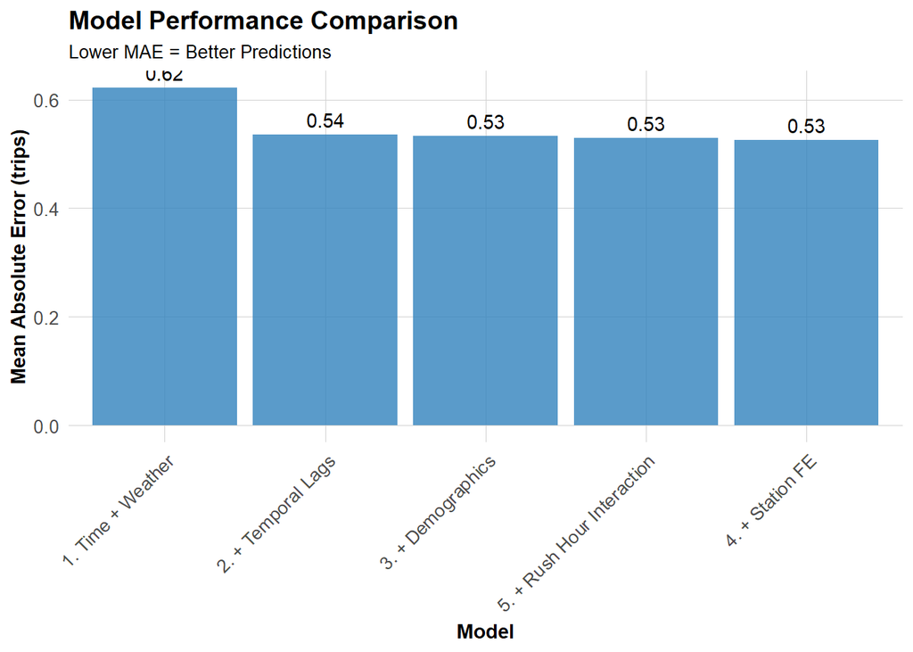

```r
ggplot(mae_results, aes(x = reorder(Model, -MAE), y = MAE)) +
  geom_col(fill = "#3182bd", alpha = 0.8) +
  geom_text(aes(label = round(MAE, 2)), vjust = -0.5) +
  labs(
    title = "Model Performance Comparison",
    subtitle = "Lower MAE = Better Predictions",
    x = "Model",
    y = "Mean Absolute Error (trips)"
  ) +
  plotTheme +
  theme(axis.text.x = element_text(angle = 45, hjust = 1))
```

# SPACE-TIME ERROR ANALYSIS

## Observed vs. Predicted

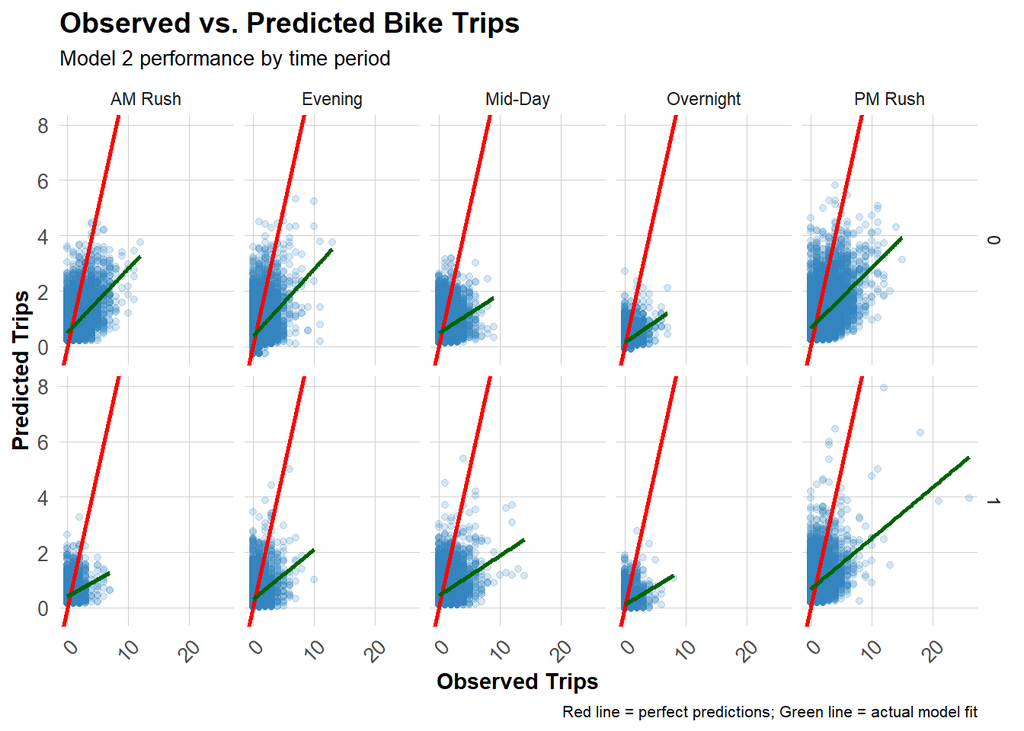

```r
test <- test %>%
  mutate(
    error = Trip_Count - pred2,
    abs_error = abs(error),
    time_of_day = case_when(
      hour < 7 ~ "Overnight",
      hour >= 7 & hour < 10 ~ "AM Rush",
      hour >= 10 & hour < 15 ~ "Mid-Day",
      hour >= 15 & hour <= 18 ~ "PM Rush",
      hour > 18 ~ "Evening"
    )
  )

# Scatter plot by time and day type
ggplot(test, aes(x = Trip_Count, y = pred2)) +
  geom_point(alpha = 0.2, color = "#3182bd") +
  geom_abline(slope = 1, intercept = 0, color = "red", linewidth = 1) +
  geom_smooth(method = "lm", se = FALSE, color = "darkgreen") +
  facet_grid(weekend ~ time_of_day) +
  labs(
    title = "Observed vs. Predicted Bike Trips",
    subtitle = "Model 2 performance by time period",
    x = "Observed Trips",
    y = "Predicted Trips",
    caption = "Red line = perfect predictions; Green line = actual model fit"
  ) +
  plotTheme
```

## Spatial Error Patterns

Are prediction errors clustered in certain parts of Philadelphia?

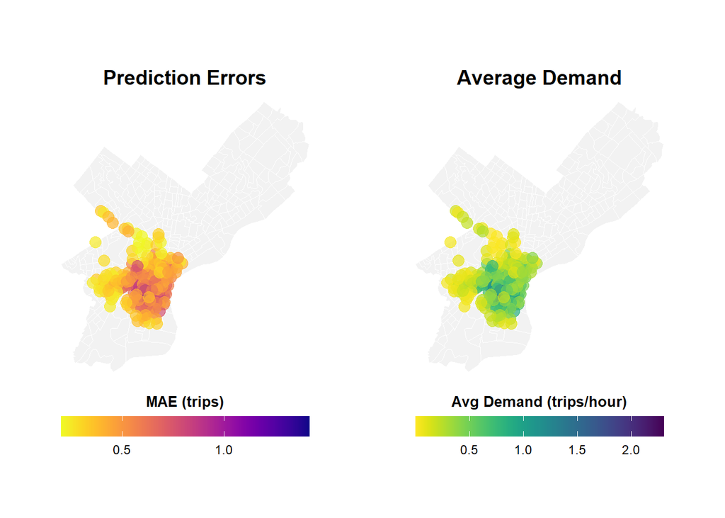

```r
# Calculate MAE by station
station_errors <- test %>%
  group_by(start_station, start_lat, start_lon) %>%
  summarize(
    MAE = mean(abs_error, na.rm = TRUE),
    avg_demand = mean(Trip_Count, na.rm = TRUE),
    .groups = "drop"
  ) %>%
  filter(!is.na(start_lat), !is.na(start_lon))

## Create Two Maps Side-by-Side with Proper Legends (sorry these maps are ugly)

# Calculate station errors
station_errors <- test %>%
  filter(!is.na(pred2)) %>%
  group_by(start_station, start_lat, start_lon) %>%
  summarize(
    MAE = mean(abs(Trip_Count - pred2), na.rm = TRUE),
    avg_demand = mean(Trip_Count, na.rm = TRUE),
    .groups = "drop"
  ) %>%
  filter(!is.na(start_lat), !is.na(start_lon))

# Map 1: Prediction Errors
p1 <- ggplot() +
  geom_sf(data = philly_census, fill = "grey95", color = "white", size = 0.2) +
  geom_point(
    data = station_errors,
    aes(x = start_lon, y = start_lat, color = MAE),
    size = 3.5,
    alpha = 0.7
  ) +
  scale_color_viridis(
    option = "plasma",
    name = "MAE\n(trips)",
    direction = -1,
    breaks = c(0.5, 1.0, 1.5),  # Fewer, cleaner breaks
    labels = c("0.5", "1.0", "1.5")
  ) +
  labs(title = "Prediction Errors",
       subtitle = "Higher in Center City") +
  mapTheme +
  theme(
    legend.position = "right",
    legend.title = element_text(size = 10, face = "bold"),
    legend.text = element_text(size = 9),
    plot.title = element_text(size = 14, face = "bold"),
    plot.subtitle = element_text(size = 10)
  ) +
  guides(color = guide_colorbar(
    barwidth = 1.5,
    barheight = 12,
    title.position = "top",
    title.hjust = 0.5
  ))

# Map 2: Average Demand
p2 <- ggplot() +
  geom_sf(data = philly_census, fill = "grey95", color = "white", size = 0.2) +
  geom_point(
    data = station_errors,
    aes(x = start_lon, y = start_lat, color = avg_demand),
    size = 3.5,
    alpha = 0.7
  ) +
  scale_color_viridis(
    option = "viridis",
    name = "Avg\nDemand",
    direction = -1,
    breaks = c(0.5, 1.0, 1.5, 2.0, 2.5),  # Clear breaks
    labels = c("0.5", "1.0", "1.5", "2.0", "2.5")
  ) +
  labs(title = "Average Demand",
       subtitle = "Trips per station-hour") +
  mapTheme +
  theme(
    legend.position = "right",
    legend.title = element_text(size = 10, face = "bold"),
    legend.text = element_text(size = 9),
    plot.title = element_text(size = 14, face = "bold"),
    plot.subtitle = element_text(size = 10)
  ) +
  guides(color = guide_colorbar(
    barwidth = 1.5,
    barheight = 12,
    title.position = "top",
    title.hjust = 0.5
  ))




# Map 1: Prediction Errors
p1 <- ggplot() +
  geom_sf(data = philly_census, fill = "grey95", color = "white", size = 0.1) +
  geom_point(
    data = station_errors,
    aes(x = start_lon, y = start_lat, color = MAE),
    size = 3.5,
    alpha = 0.7
  ) +
  scale_color_viridis(
    option = "plasma",
    name = "MAE (trips)",
    direction = -1,
    breaks = c(0.5, 1.0, 1.5),
    labels = c("0.5", "1.0", "1.5")
  ) +
  labs(title = "Prediction Errors") +
  mapTheme +
  theme(
    legend.position = "bottom",
    legend.title = element_text(size = 10, face = "bold"),
    legend.text = element_text(size = 9),
    plot.title = element_text(size = 14, face = "bold", hjust = 0.5)
  ) +
  guides(color = guide_colorbar(
    barwidth = 12,
    barheight = 1,
    title.position = "top",
    title.hjust = 0.5
  ))

# Map 2: Average Demand
p2 <- ggplot() +
  geom_sf(data = philly_census, fill = "grey95", color = "white", size = 0.1) +
  geom_point(
    data = station_errors,
    aes(x = start_lon, y = start_lat, color = avg_demand),
    size = 3.5,
    alpha = 0.7
  ) +
  scale_color_viridis(
    option = "viridis",
    name = "Avg Demand (trips/hour)",
    direction = -1,
    breaks = c(0.5, 1.0, 1.5, 2.0, 2.5),
    labels = c("0.5", "1.0", "1.5", "2.0", "2.5")
  ) +
  labs(title = "Average Demand") +
  mapTheme +
  theme(
    legend.position = "bottom",
    legend.title = element_text(size = 10, face = "bold"),
    legend.text = element_text(size = 9),
    plot.title = element_text(size = 14, face = "bold", hjust = 0.5)
  ) +
  guides(color = guide_colorbar(
    barwidth = 12,
    barheight = 1,
    title.position = "top",
    title.hjust = 0.5
  ))

# Combine
(p1 | p2)
```

## Temporal Error Patterns

When are we most wrong?

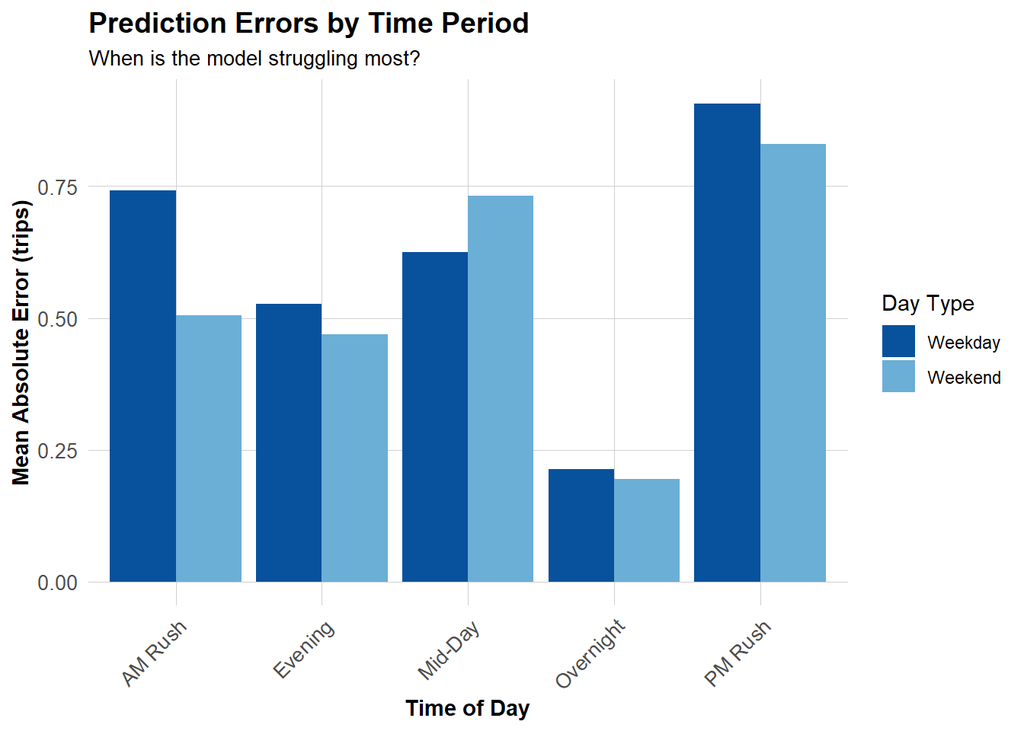

```r
# MAE by time of day and day type
temporal_errors <- test %>%
  group_by(time_of_day, weekend) %>%
  summarize(
    MAE = mean(abs_error, na.rm = TRUE),
    .groups = "drop"
  ) %>%
  mutate(day_type = ifelse(weekend == 1, "Weekend", "Weekday"))

ggplot(temporal_errors, aes(x = time_of_day, y = MAE, fill = day_type)) +
  geom_col(position = "dodge") +
  scale_fill_manual(values = c("Weekday" = "#08519c", "Weekend" = "#6baed6")) +
  labs(
    title = "Prediction Errors by Time Period",
    subtitle = "When is the model struggling most?",
    x = "Time of Day",
    y = "Mean Absolute Error (trips)",
    fill = "Day Type"
  ) +
  plotTheme +
  theme(axis.text.x = element_text(angle = 45, hjust = 1))
```

## Errors and Demographics

Are prediction errors related to neighborhood characteristics?

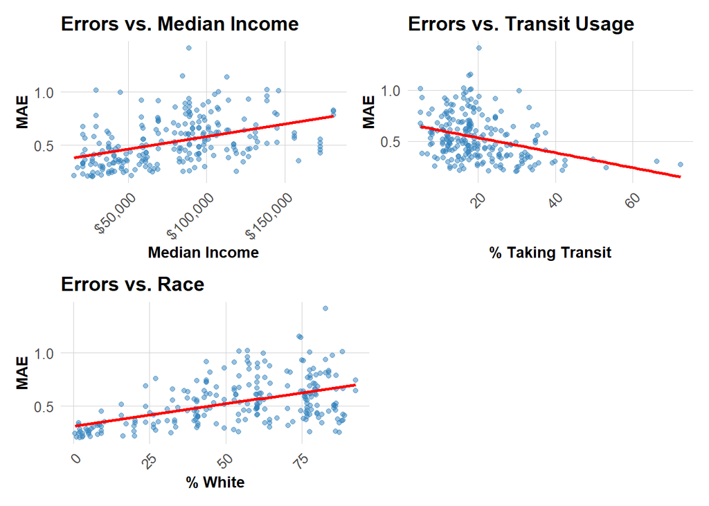

```r
# Join demographic data to station errors
station_errors_demo <- station_errors %>%
  left_join(
    station_attributes %>% select(start_station, Med_Inc, Percent_Taking_Transit, Percent_White),
    by = "start_station"
  ) %>%
  filter(!is.na(Med_Inc))

# Create plots
p1 <- ggplot(station_errors_demo, aes(x = Med_Inc, y = MAE)) +
  geom_point(alpha = 0.5, color = "#3182bd") +
  geom_smooth(method = "lm", se = FALSE, color = "red") +
  scale_x_continuous(labels = scales::dollar) +
  labs(title = "Errors vs. Median Income", x = "Median Income", y = "MAE") +
  plotTheme

p2 <- ggplot(station_errors_demo, aes(x = Percent_Taking_Transit, y = MAE)) +
  geom_point(alpha = 0.5, color = "#3182bd") +
  geom_smooth(method = "lm", se = FALSE, color = "red") +
  labs(title = "Errors vs. Transit Usage", x = "% Taking Transit", y = "MAE") +
  plotTheme

p3 <- ggplot(station_errors_demo, aes(x = Percent_White, y = MAE)) +
  geom_point(alpha = 0.5, color = "#3182bd") +
  geom_smooth(method = "lm", se = FALSE, color = "red") +
  labs(title = "Errors vs. Race", x = "% White", y = "MAE") +
  plotTheme

(p1 | p2) / (p3 | plot_spacer())
```

#Q4 Analysis (Lab 5)

```r
# Read Q4 2025 data
indegoQ4 <- read_csv(here("data/indego-trips-2025-q4.csv"))

# Quick look at the data
glimpse(indegoQ4)
```

```
Rows: 325,361
Columns: 15
$ trip_id             <dbl> 1251856736, 1251858742, 1251857426, 1251856653, 12…
$ duration            <dbl> 5, 38, 15, 1, 21, 12, 7, 9, 10, 15, 12, 12, 11, 9,…
$ start_time          <chr> "10/1/2025 0:00", "10/1/2025 0:01", "10/1/2025 0:0…
$ end_time            <chr> "10/1/2025 0:05", "10/1/2025 0:39", "10/1/2025 0:1…
$ start_station       <dbl> 3382, 3277, 3028, 3024, 3063, 3213, 3024, 3362, 30…
$ start_lat           <dbl> 39.95038, 39.98306, 39.94061, 39.94822, 39.94633, …
$ start_lon           <dbl> -75.17309, -75.16738, -75.14958, -75.20908, -75.16…
$ end_station         <dbl> 3064, 3277, 3100, 3024, 3112, 3187, 3410, 3073, 30…
$ end_lat             <dbl> 39.93840, 39.98306, 39.92777, 39.94822, 39.95373, …
$ end_lon             <dbl> -75.17327, -75.16738, -75.15103, -75.20908, -75.21…
$ bike_id             <chr> "29339", "02685", "30333", "29577", "03684", "1172…
$ plan_duration       <dbl> 30, 30, 30, 365, 30, 30, 365, 30, 30, 30, 1, 30, 1…
$ trip_route_category <chr> "One Way", "Round Trip", "One Way", "Round Trip", …
$ passholder_type     <chr> "Indego30", "Indego30", "Indego30", "Indego365", "…
$ bike_type           <chr> "electric", "standard", "electric", "electric", "s…
```

```r
cat("Total Trips in Q4:", nrow(indegoQ4), "\n")
```

```
Total Trips in Q4: 325361
```

```r
cat("Date Range:",
    min(mdy_hm(indegoQ4$start_time)), "to",
    max(mdy_hm(indegoQ4$start_time)), "\n")
```

```
Date Range: 1759276800 to 1767225420
```

```r
# How many unique stations?
cat("Unique start stations:", length(unique(indegoQ4$start_station)), "\n")
```

```
Unique start stations: 294
```

```r
# Trip types
table(indegoQ4$trip_route_category)
```

```
   One Way Round Trip
    308569      16792
```

```r
# Passholder types
table(indegoQ4$passholder_type)
```

```
 Day Pass  Indego30 Indego365      NULL   Walk-up
     8988    168054    127625        17     20677
```

```r
# Bike types
table(indegoQ4$bike_type)
```

```
electric standard
  225474    99887
```

```r
indegoQ4 <- indegoQ4 %>%
  mutate(
    # Parse datetime
    start_datetime = mdy_hm(start_time),
    end_datetime = mdy_hm(end_time),

    # Create hourly bins
    interval60 = floor_date(start_datetime, unit = "hour"),

    # Extract time features
    week = week(interval60),
    month = month(interval60, label = TRUE),
    dotw = wday(interval60, label = TRUE),
    hour = hour(interval60),
    date = as.Date(interval60),

    # Create useful indicators
    weekend = ifelse(dotw %in% c("Sat", "Sun"), 1, 0),
    rush_hour = ifelse(hour %in% c(7, 8, 9, 16, 17, 18), 1, 0)
  )

# Look at temporal features
head(indegoQ4 %>% select(start_datetime, interval60, week, dotw, hour, weekend))
```

```
# A tibble: 6 × 6
  start_datetime      interval60           week dotw   hour weekend
  <dttm>              <dttm>              <dbl> <ord> <int>   <dbl>
1 2025-10-01 00:00:00 2025-10-01 00:00:00    40 Wed       0       0
2 2025-10-01 00:01:00 2025-10-01 00:00:00    40 Wed       0       0
3 2025-10-01 00:01:00 2025-10-01 00:00:00    40 Wed       0       0
4 2025-10-01 00:04:00 2025-10-01 00:00:00    40 Wed       0       0
5 2025-10-01 00:04:00 2025-10-01 00:00:00    40 Wed       0       0
6 2025-10-01 00:04:00 2025-10-01 00:00:00    40 Wed       0       0
```

## EDA for Q4

### Trips Over Time

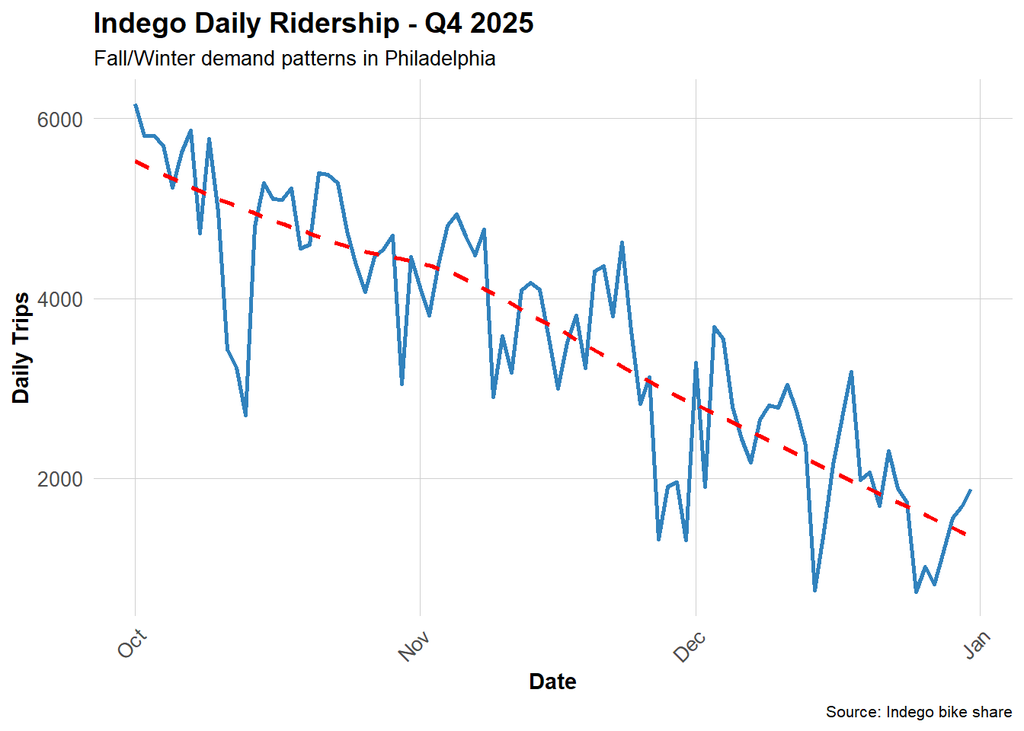

```r
# Daily trip counts
daily_trips <- indegoQ4 %>%
  group_by(date) %>%
  summarize(trips = n())

ggplot(daily_trips, aes(x = date, y = trips)) +
  geom_line(color = "#3182bd", linewidth = 1) +
  geom_smooth(se = FALSE, color = "red", linetype = "dashed") +
  labs(
    title = "Indego Daily Ridership - Q4 2025",
    subtitle = "Fall/Winter demand patterns in Philadelphia",
    x = "Date",
    y = "Daily Trips",
    caption = "Source: Indego bike share"
  ) +
  plotTheme
```

### Hourly Patterns

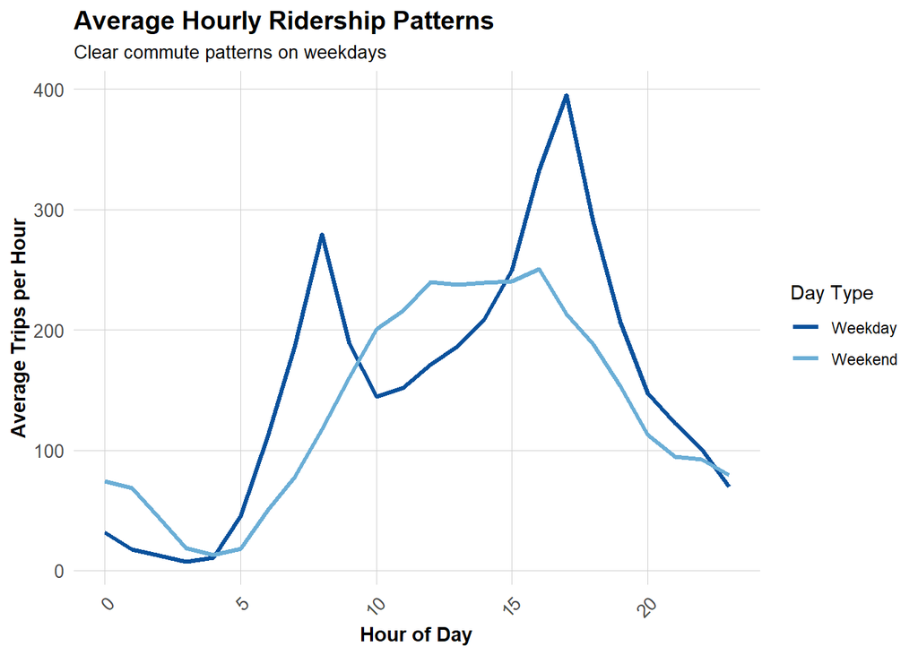

```r
# Average trips by hour and day type
hourly_patterns <- indegoQ4 %>%
  group_by(hour, weekend) %>%
  summarize(avg_trips = n() / n_distinct(date)) %>%
  mutate(day_type = ifelse(weekend == 1, "Weekend", "Weekday"))

ggplot(hourly_patterns, aes(x = hour, y = avg_trips, color = day_type)) +
  geom_line(linewidth = 1.2) +
  scale_color_manual(values = c("Weekday" = "#08519c", "Weekend" = "#6baed6")) +
  labs(
    title = "Average Hourly Ridership Patterns",
    subtitle = "Clear commute patterns on weekdays",
    x = "Hour of Day",
    y = "Average Trips per Hour",
    color = "Day Type"
  ) +
  plotTheme
```

Interestingly, there are more peaks in ridership during the week, especialy what seems to be the start of the work-day around 8 am and at the end of the day around 17:00/5pm. While weekend ridership follows this general trend, it does not have any strong peaks. Ridership during the weekend is highest between 10 am and 4-5 pm.

### Get Weather Data

```r
weather_Q4 <- riem_measures(
  station = "PHL",
  date_start = "2025-10-01",
  date_end = "2025-12-31")

weather_Q4processed <- weather_Q4 %>%
  mutate(
    interval60 = floor_date(valid, unit = "hour"),#floor date rounds the timestamp to nearest unit of time, which for us is the hour behind.
    Temperature = tmpf,  # Temperature in F
    Precipitation = ifelse(is.na(p01i), 0, p01i),  # Hourly precip in inches
    Wind_Speed = sknt  # Wind speed in knots. 1 nt = about 1.15 miles/hour
  ) %>%
  select(interval60, Temperature, Precipitation, Wind_Speed) %>%
  distinct(interval60, .keep_all = TRUE)

#missing any hours? If so, we'll have to use the interpolate function
weather_completeQ4 <- weather_Q4processed %>%
  complete(interval60 = seq(min(interval60), max(interval60), by = "hour")) %>% #creates seq between the earliest and the latest timestamp, while complete puts in an empty row for any missing hour. it will have NA for temp, percip, and wind speed.
  fill(Temperature, Precipitation, Wind_Speed, .direction = "down") #this is the actual interpolation, it will use the same value as before. Assumption that weather conditions won't change too quickly

# Look at the weather
summary(weather_completeQ4 %>% select(Temperature, Precipitation, Wind_Speed))
```

```
  Temperature    Precipitation        Wind_Speed
 Min.   :18.00   Min.   :0.000000   Min.   : 0.000
 1st Qu.:38.00   1st Qu.:0.000000   1st Qu.: 5.000
 Median :49.00   Median :0.000000   Median : 8.000
 Mean   :48.36   Mean   :0.001257   Mean   : 8.617
 3rd Qu.:58.00   3rd Qu.:0.000000   3rd Qu.:12.000
 Max.   :83.00   Max.   :0.250000   Max.   :29.000
```

### Join Census Data to Stations

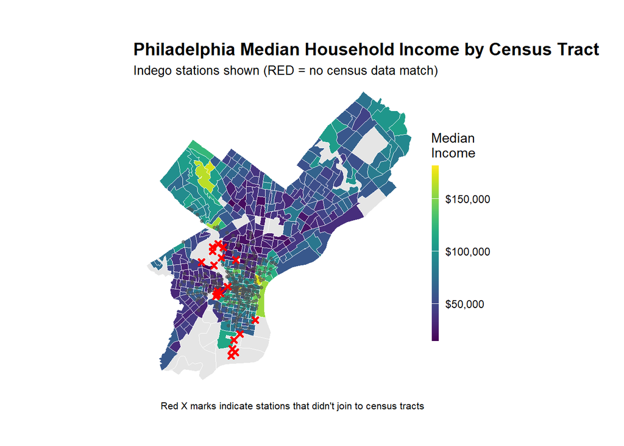

```r
#using the same Philly census from above
philly_censusQ4 <- philly_census


# Create sf object for stations
stations_sfQ4 <- indegoQ4 %>%
  distinct(start_station, start_lat, start_lon) %>%
  filter(!is.na(start_lat), !is.na(start_lon)) %>%
  st_as_sf(coords = c("start_lon", "start_lat"), crs = 4326)

# Spatial join to get census tract for each station
stations_censusQ4 <- st_join(stations_sfQ4, philly_censusQ4, left = TRUE) %>%
  st_drop_geometry()

# Look at the result - investigate whether all of the stations joined to census data -- according to the map above there are stations in non-residential tracts.

stations_for_mapQ4 <- indegoQ4 %>%
  distinct(start_station, start_lat, start_lon) %>%
  filter(!is.na(start_lat), !is.na(start_lon)) %>%
  left_join(
    stations_censusQ4 %>% select(start_station, Med_Inc),
    by = "start_station"
  ) %>%
  mutate(has_census = !is.na(Med_Inc))

# Add back to trip data

valid_stationsQ4 <- stations_censusQ4 %>%
  filter(!is.na(Med_Inc)) %>%
  pull(start_station)

indego_censusQ4 <- indegoQ4 %>%
  filter(start_station %in% valid_stationsQ4) %>%
  left_join(
    stations_censusQ4 %>%
      select(start_station, Med_Inc, Percent_Taking_Transit,
             Percent_White, Total_Pop),
    by = "start_station"
  )

# Prepare data for visualization
stations_for_map <- indego %>%
  distinct(start_station, start_lat, start_lon) %>%
  filter(!is.na(start_lat), !is.na(start_lon)) %>%
  left_join(
    stations_census %>% select(start_station, Med_Inc),
    by = "start_station"
  ) %>%
  mutate(has_census = !is.na(Med_Inc))

# Create the map showing problem stations
ggplot() +
  geom_sf(data = philly_census, aes(fill = Med_Inc), color = "white", size = 0.1) +
  scale_fill_viridis(
    option = "viridis",
    name = "Median\nIncome",
    labels = scales::dollar,
    na.value = "grey90"
  ) +
  # Stations with census data (small grey dots)
  geom_point(
    data = stations_for_map %>% filter(has_census),
    aes(x = start_lon, y = start_lat),
    color = "grey30", size = 1, alpha = 0.6
  ) +
  # Stations WITHOUT census data (red X marks the spot)
  geom_point(
    data = stations_for_map %>% filter(!has_census),
    aes(x = start_lon, y = start_lat),
    color = "red", size = 1, shape = 4, stroke = 1.5
  ) +
  labs(
    title = "Philadelphia Median Household Income by Census Tract",
    subtitle = "Indego stations shown (RED = no census data match)",
    caption = "Red X marks indicate stations that didn't join to census tracts"
  ) +
  mapTheme
```